# 流浪者夜歌

Warte nur, balde ruhest du auch.

# Gruppenarbeit_NEU

四月 30, 2020

# Gruppenarbeit: OS Statistische Methoden

Hening Wang, Yuanyuan Hou, Ingibjörg Steingrímsdóttir

13. Januar 2020

```
Dozent: Dr. Fabian Schlotterbeck
Deutsches Seminar, Universität Tübingen
```

load package and data frame

```r
library(lme4)
library(lmerTest)
```

```r
library(ggplot2)
load("data_zur_Bearbeitung.RData")
```

Zunächst werden die Faktoren und Faktorstufen definiert.

```r
factor1 <- as.factor(c("level1.1","level1.2"))
factor2 <- as.factor(c("level2.1","level2.2"))
```

aggregate…

```r
agg_data <- aggregate(rt~factor1+factor2+participant, data, mean)
```

Aufgabe 1 Werft einen Blick auf die Verteilungen der Reaktionszeiten in den vier Bedingungen. Histogram aller Reaktionszeiten in den vier Bedingungen

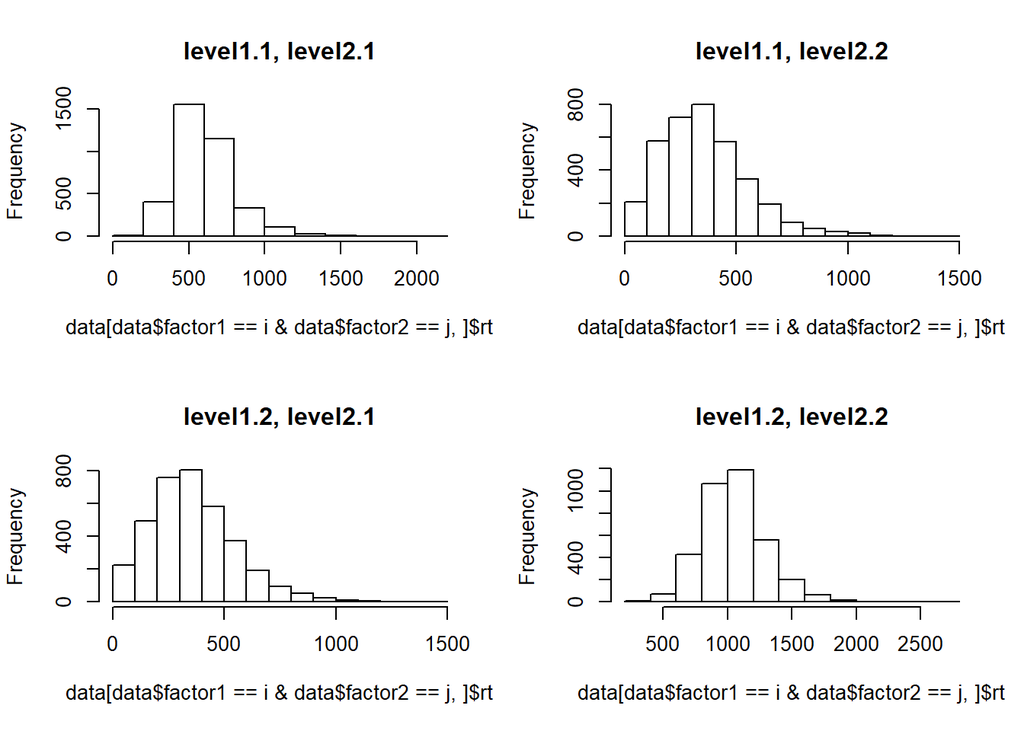

[output not shown]

```r
par(mfrow=c(2,2))
for (i in levels(factor1)){
  for (j in levels(factor2)){
    hist(data[data$factor1==i & data$factor2==j,]$rt, main = paste(i,j, sep=", "))
  }
}
```

Aufgabe 2 Betrachtet eine simulierte Versuchsperson genauer. Histogram der Reaktionszeiten des ersten Teilnehmers in den vier Bedingungen

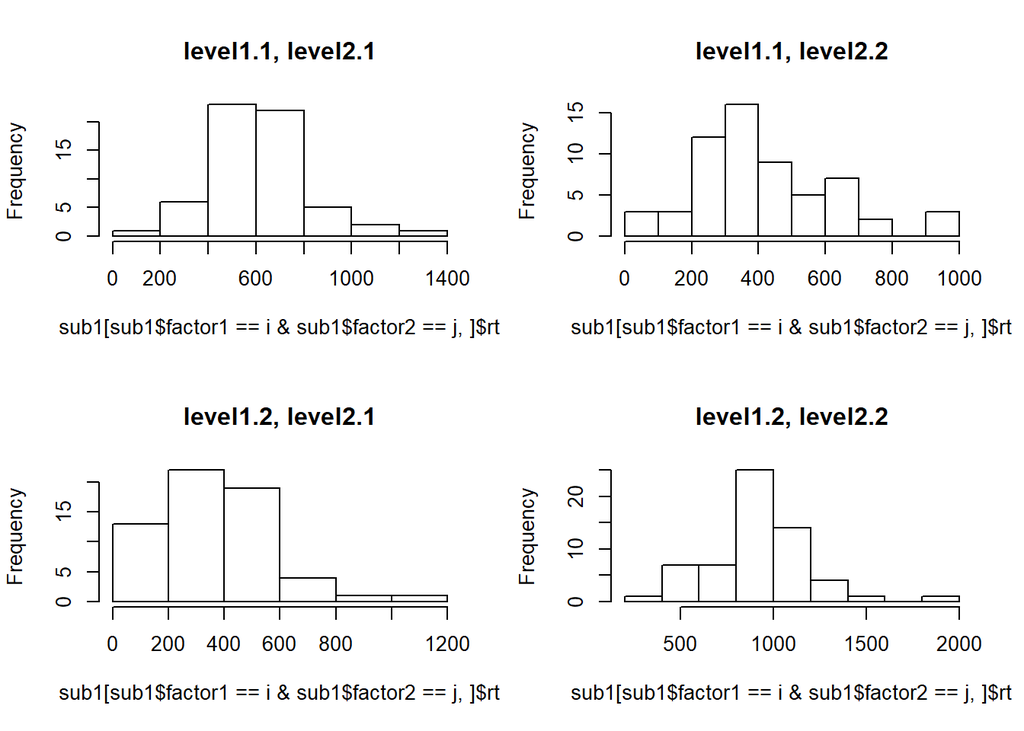

```r
sub1 <- subset(data, participant=="pp1")
par(mfrow=c(2,2))
for (i in levels(factor1)){
  for (j in levels(factor2)){
    hist(sub1[sub1$factor1==i & sub1$factor2==j,]$rt, main = paste(i,j, sep=", "))
  }
}
```

Quantil der Reaktionszeiten des ersten Teilnehmers in den vier Bedingungen

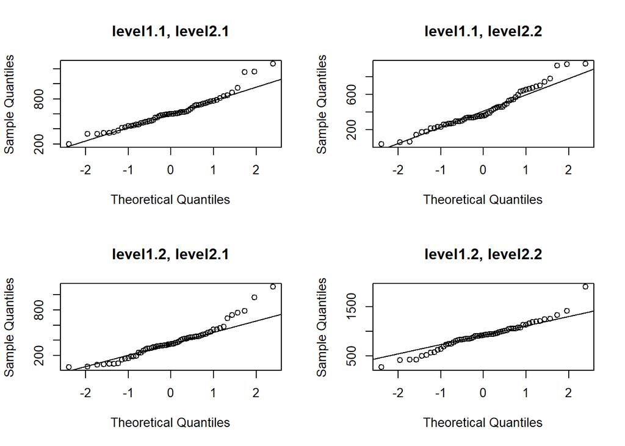

```
Anhand der Form des Histograms und Quantils ist es deutlich, dass die Verteilung grob der Normalverteilung folgt.

Beschreibung der Aufgabe 2:
In der Bedingung [level1.1, level2.1]:
µ = 615.4299
σ = 202.0015
In der Bedingung [level1.1, level2.2]:
µ =419.1368
σ = 206.9496
In der Bedingung [level1.2, level2.1]:
µ =377.204
σ = 208.7926
In der Bedingung [level1.2, level2.2]:
µ =913.4193
σ = 266.4935
Wir nennen pp1 als simulierte Versuchsperson. Wie das Schaubild darstellt, folgt die Reaktionszeit der Bedingung [level1.1, level2.1] der Normalverteilung. Der Mittelwert ist 615.4299, es entspricht dem Diagram.
Die Standardabweichung der Bedingung 1 ist fast gleich wie die der Bedingung 2 und Bedingung 3, deshalb sehen die Verteilungen von diesen drei Bedingungen ähnlich aus.
Bei der Bedingung [level1.2, level2.2] ist alles anders. der Mittelwert ist 913.4193, er ist viel größer als die Mittelwerte der anderen 3 Bedingen. Obwohl die Reaktionszeiten der Bedingung 4 fast der Normalverteilung folgen, ist die Standardabweichung ein bisschen größer als die der anderen drei.
```

```r
par(mfrow=c(2,2))
for (i in levels(factor1)){
  for (j in levels(factor2)){
    qqnorm(sub1[data$factor1==i & data$factor2==j,]$rt, main = paste(i,j, sep=", "))
    qqline(sub1[data$factor1==i & data$factor2==j,]$rt, main = paste(i,j, sep=", "))
  }
}
```

Aufgabe 3 Bildet für alle Versuchspersonen die Mittelwerte der Reaktionszeiten in den vier Bedingungen.

```r
aggregate(rt~factor1+factor2, data, mean)
```

```
##    factor1  factor2        rt
## 1 level1.1 level2.1  605.0275
## 2 level1.2 level2.1  361.4941
## 3 level1.1 level2.2  357.7497
## 4 level1.2 level2.2 1048.5678
```

[output not shown]

Aufgabe 4 Beschreibt die Verteilungen der Versuchspersonenmittelwerte in den vier Bedingungen. Da die Verteilung der Reaktionszeiten der Normalverteilung ähnelt, verwenden wir Mittelwert als Lagemaße und Standard Derivation als Streuungsmaße. Lage- und Streuungsmaße von Bedingung 1

```r
Bedingung_1 <- subset(agg_data, factor1=="level1.1" & factor2=="level2.1")
Bedingung_1.means<-round(mean(Bedingung_1$rt),4)
Bedingung_1.sd <- round(sd(Bedingung_1$rt),4)
Bedingung_1.se <- round(Bedingung_1.sd/sqrt(60),4)
paste("Bedingung_1.means=",Bedingung_1.means)
```

```
## [1] "Bedingung_1.means= 605.0275"
```

```r
paste("Bedingung_1.sd=",Bedingung_1.sd)
```

```
## [1] "Bedingung_1.sd= 31.5911"
```

Lage- und Streuungsmaße von Bedingung 2

```r
Bedingung_2 <- subset(agg_data, factor1=="level1.1" & factor2=="level2.2")
Bedingung_2.means <- round(mean(Bedingung_2$rt),4)
Bedingung_2.sd <- round(sd(Bedingung_2$rt),4)
Bedingung_2.se <- round(Bedingung_2.sd/sqrt(60),4)
paste("Bedingung_2.means=",Bedingung_2.means)
```

```
## [1] "Bedingung_2.means= 357.7497"
```

```r
paste("Bedingung_2.sd=",Bedingung_2.sd)
```

```
## [1] "Bedingung_2.sd= 41.9532"
```

Lage- und Streuungsmaße von Bedingung 3

```r
Bedingung_3 <- subset(agg_data, factor1=="level1.2" & factor2=="level2.1")
Bedingung_3.means <- round(mean(Bedingung_3$rt),4)
Bedingung_3.sd <- round(sd(Bedingung_3$rt),4)
Bedingung_4.se <- round(Bedingung_3.sd/sqrt(60),4)
paste("Bedingung_3.means=",Bedingung_3.means)
```

```
## [1] "Bedingung_3.means= 361.4941"
```

```r
paste("Bedingung_3.sd=",Bedingung_3.sd)
```

```
## [1] "Bedingung_3.sd= 33.524"
```

Lage- und Streuungsmaße von Bedingung 4

```r
Bedingung_4 <- subset(agg_data, factor1=="level1.2" & factor2=="level2.2")
Bedingung_4.means <- round(mean(Bedingung_4$rt),4)
Bedingung_4.sd <- round(sd(Bedingung_4$rt),4)
Bedingung_4.se <- round(Bedingung_4.sd/sqrt(60),4)
paste("Bedingung_4.means=",Bedingung_4.means)
```

```
## [1] "Bedingung_4.means= 1048.5678"
```

```r
paste("Bedingung_4.sd=",Bedingung_4.sd)
```

```
## [1] "Bedingung_4.sd= 82.6853"
```

[output not shown]

Aufgabe 5 Berechnet Konfidenzintervalle für die Versuchspersonenmittelwerte in den vier Bedingungen.

```r
Liste_aller_vier_Bedin. <- list(Bedingung_1,Bedingung_2,Bedingung_3,Bedingung_4)
t.test(Bedingung_1$rt)
```

```
##
##  One Sample t-test
##
## data:  Bedingung_1$rt
## t = 148.35, df = 59, p-value < 2.2e-16
## alternative hypothesis: true mean is not equal to 0
## 95 percent confidence interval:
##  596.8666 613.1883
## sample estimates:
## mean of x
##  605.0275
```

```r
upper <- rep(NA,4)
lower <- rep(NA,4)

for (i in 1:4) {
  lower[i] <- round(t.test(Liste_aller_vier_Bedin.[[i]]$rt)$conf.int[1],4)
  upper[i] <- round(t.test(Liste_aller_vier_Bedin.[[i]]$rt)$conf.int[2],4)
}
cis <- cbind(lower,upper)
cis
```

```
##          lower     upper
## [1,]  596.8666  613.1883
## [2,]  346.9121  368.5874
## [3,]  352.8339  370.1543
## [4,] 1027.2079 1069.9277
```

[output not shown]

Aufgabe 6

```r
summary(lmer(rt~factor1*factor2+(1|participant), data = agg_data))
```

```
## Linear mixed model fit by REML. t-tests use Satterthwaite's method [
## lmerModLmerTest]
## Formula: rt ~ factor1 * factor2 + (1 | participant)
##    Data: agg_data
##
## REML criterion at convergence: 2547.2
##
## Scaled residuals:
##     Min      1Q  Median      3Q     Max
## -3.1900 -0.5747  0.0101  0.5876  3.8684
##
## Random effects:
##  Groups      Name        Variance Std.Dev.
##  participant (Intercept)  197.3   14.05
##  Residual                2482.4   49.82
## Number of obs: 240, groups:  participant, 60
##
## Fixed effects:
##                                 Estimate Std. Error       df t value Pr(>|t|)
## (Intercept)                      605.027      6.683  232.222   90.53   <2e-16
## factor1level1.2                 -243.533      9.096  177.000  -26.77   <2e-16
## factor2level2.2                 -247.278      9.096  177.000  -27.18   <2e-16
## factor1level1.2:factor2level2.2  934.351     12.864  177.000   72.63   <2e-16
##
## (Intercept)                     ***
## factor1level1.2                 ***
## factor2level2.2                 ***
## factor1level1.2:factor2level2.2 ***
## ---
## Signif. codes:  0 '***' 0.001 '**' 0.01 '*' 0.05 '.' 0.1 ' ' 1
##
## Correlation of Fixed Effects:
##             (Intr) fc11.2 fc22.2
## fctr1lvl1.2 -0.681
## fctr2lvl2.2 -0.681  0.500
## fc11.2:22.2  0.481 -0.707 -0.707
```

[output not shown]

Aufteilung der Aufgaben: Hening Wang ist zuständig fürs Programieren des R-Codes und Erstellen und Zusammenfassen der RMD-Datei. Yuanyuan Hou ist zuständig für die Beschreibung der Aufgabe 1-4. Ingibjörg Steingrímsdóttir ist zuständig für die Beschreibung der Aufgabe 5-6.

# Statistische Methoden

四月 30, 2020 语言学

```
Dozent: Dr. Fabian Schlotterbeck
Deutsches Seminar, Universität Tübingen
```

load package and data frame

[output not shown]

```
library(lme4)
```

[output not shown]

```
library(lmerTest)
```

[output not shown]

```
library(ggplot2)
load("data_zur_Bearbeitung.RData")
```

Zunächst werden die Faktoren und Faktorstufen definiert.

[output not shown]

```
factor1 <- as.factor(c("level1.1","level1.2"))
factor2 <- as.factor(c("level2.1","level2.2"))
```

aggregate…

[output not shown]

```
agg_data <- aggregate(rt~factor1+factor2+participant, data, mean)
```

Aufgabe 1 Werft einen Blick auf die Verteilungen der Reaktionszeiten in  
den vier Bedingungen. Histogram aller Reaktionszeiten in den vier  
Bedingungen

[output not shown]

```
par(mfrow=c(2,2))
for (i in levels(factor1)){
  for (j in levels(factor2)){
    hist(data[data$factor1==i & data$factor2==j,]$rt, main = paste(i,j, sep=", "))
  }
}
```

[figure not shown]

[output not shown]

Aufgabe 2 Betrachtet eine simulierte Versuchsperson genauer. Histogram  
der Reaktionszeiten des ersten Teilnehmers in den vier Bedingungen

[output not shown]

```
sub1 <- subset(data, participant=="pp1")
par(mfrow=c(2,2))
for (i in levels(factor1)){
  for (j in levels(factor2)){
    hist(sub1[sub1$factor1==i & sub1$factor2==j,]$rt, main = paste(i,j, sep=", "))
  }
}
```

[figure not shown]

Quantil der Reaktionszeiten des ersten Teilnehmers in den vier  
Bedingungen

[output not shown]

```
par(mfrow=c(2,2))
for (i in levels(factor1)){
  for (j in levels(factor2)){
    qqnorm(sub1[data$factor1==i & data$factor2==j,]$rt, main = paste(i,j, sep=", "))
    qqline(sub1[data$factor1==i & data$factor2==j,]$rt, main = paste(i,j, sep=", "))
  }
}
```

[figure not shown]

```
Anhand der Form des Histograms und Quantils ist es deutlich, dass die Verteilung grob der Normalverteilung folgt.

Beschreibung der Aufgabe 2:
In der Bedingung [level1.1, level2.1]:
µ = 615.4299
σ = 202.0015
In der Bedingung [level1.1, level2.2]:
µ =419.1368
σ = 206.9496
In der Bedingung [level1.2, level2.1]:
µ =377.204
σ = 208.7926
In der Bedingung [level1.2, level2.2]:
µ =913.4193
σ = 266.4935
Wir nennen pp1 als simulierte Versuchsperson. Wie das Schaubild darstellt, folgt die Reaktionszeit der Bedingung [level1.1, level2.1] der Normalverteilung. Der Mittelwert ist 615.4299, es entspricht dem Diagram.
Die Standardabweichung der Bedingung 1 ist fast gleich wie die der Bedingung 2 und Bedingung 3, deshalb sehen die Verteilungen von diesen drei Bedingungen ähnlich aus.
Bei der Bedingung [level1.2, level2.2] ist alles anders. der Mittelwert ist 913.4193, er ist viel größer als die Mittelwerte der anderen 3 Bedingen. Obwohl die Reaktionszeiten der Bedingung 4 fast der Normalverteilung folgen, ist die Standardabweichung ein bisschen größer als die der anderen drei.
```

Aufgabe 3 Bildet für alle Versuchspersonen die Mittelwerte der  
Reaktionszeiten in den vier Bedingungen.

[output not shown]

```
aggregate(rt~factor1+factor2, data, mean)
```

[output not shown]

Aufgabe 4 Beschreibt die Verteilungen der Versuchspersonenmittelwerte in  
den vier Bedingungen. Da die Verteilung der Reaktionszeiten der  
Normalverteilung ähnelt, verwenden wir Mittelwert als Lagemaße und  
Standard Derivation als Streuungsmaße. Lage- und Streuungsmaße von  
Bedingung 1

[output not shown]

```
Bedingung_1 <- subset(agg_data, factor1=="level1.1" & factor2=="level2.1")
Bedingung_1.means<-round(mean(Bedingung_1$rt),4)
Bedingung_1.sd <- round(sd(Bedingung_1$rt),4)
Bedingung_1.se <- round(Bedingung_1.sd/sqrt(60),4)
paste("Bedingung_1.means=",Bedingung_1.means)
```

```
## [1] "Bedingung_1.means= 605.0275"
```

[output not shown]

```
paste("Bedingung_1.sd=",Bedingung_1.sd)
```

```
## [1] "Bedingung_1.sd= 31.5911"
```

Lage- und Streuungsmaße von Bedingung 2

[output not shown]

```
Bedingung_2 <- subset(agg_data, factor1=="level1.1" & factor2=="level2.2")
Bedingung_2.means <- round(mean(Bedingung_2$rt),4)
Bedingung_2.sd <- round(sd(Bedingung_2$rt),4)
Bedingung_2.se <- round(Bedingung_2.sd/sqrt(60),4)
paste("Bedingung_2.means=",Bedingung_2.means)
```

```
## [1] "Bedingung_2.means= 357.7497"
```

[output not shown]

```
paste("Bedingung_2.sd=",Bedingung_2.sd)
```

```
## [1] "Bedingung_2.sd= 41.9532"
```

Lage- und Streuungsmaße von Bedingung 3

[output not shown]

```
Bedingung_3 <- subset(agg_data, factor1=="level1.2" & factor2=="level2.1")
Bedingung_3.means <- round(mean(Bedingung_3$rt),4)
Bedingung_3.sd <- round(sd(Bedingung_3$rt),4)
Bedingung_4.se <- round(Bedingung_3.sd/sqrt(60),4)
paste("Bedingung_3.means=",Bedingung_3.means)
```

```
## [1] "Bedingung_3.means= 361.4941"
```

[output not shown]

```
paste("Bedingung_3.sd=",Bedingung_3.sd)
```

```
## [1] "Bedingung_3.sd= 33.524"
```

Lage- und Streuungsmaße von Bedingung 4

[output not shown]

```
Bedingung_4 <- subset(agg_data, factor1=="level1.2" & factor2=="level2.2")
Bedingung_4.means <- round(mean(Bedingung_4$rt),4)
Bedingung_4.sd <- round(sd(Bedingung_4$rt),4)
Bedingung_4.se <- round(Bedingung_4.sd/sqrt(60),4)
paste("Bedingung_4.means=",Bedingung_4.means)
```

```
## [1] "Bedingung_4.means= 1048.5678"
```

[output not shown]

```
paste("Bedingung_4.sd=",Bedingung_4.sd)
```

[output not shown]

Aufgabe 5 Berechnet Konfidenzintervalle für die  
Versuchspersonenmittelwerte in den vier Bedingungen.

[output not shown]

```
Liste_aller_vier_Bedin. <- list(Bedingung_1,Bedingung_2,Bedingung_3,Bedingung_4)
t.test(Bedingung_1$rt)
```

```
##
##  One Sample t-test
##
## data:  Bedingung_1$rt
## t = 148.35, df = 59, p-value < 2.2e-16
## alternative hypothesis: true mean is not equal to 0
## 95 percent confidence interval:
##  596.8666 613.1883
## sample estimates:
## mean of x
##  605.0275
```

[output not shown]

```
upper <- rep(NA,4)
lower <- rep(NA,4)

for (i in 1:4) {
  lower[i] <- round(t.test(Liste_aller_vier_Bedin.[[i]]$rt)$conf.int[1],4)
  upper[i] <- round(t.test(Liste_aller_vier_Bedin.[[i]]$rt)$conf.int[2],4)
}
cis <- cbind(lower,upper)
cis
```

[output not shown]

Aufgabe 6

[output not shown]

```
summary(lmer(rt~factor1*factor2+(1|participant), data = agg_data))
```

[output not shown]

Aufteilung der Aufgaben: Hening Wang ist zuständig fürs Programieren des  
R-Codes und Erstellen und Zusammenfassen der RMD-Datei. Yuanyuan Hou ist  
zuständig für die Beschreibung der Aufgabe 1-4. Ingibjörg  
Steingrímsdóttir ist zuständig für die Beschreibung der Aufgabe 5-6.

# What's speech act? (Levinson 1983)文献总结

四月 22, 2020 语言学

Author informationStephen C.Levinson is a British linguist, educated at Cambridge in the UK and UCB in the USA, known for his studies of pragmatics and the relationship between human language and cognition. He is currently one of the scientific directors of the MPI for Psycholinguistics in Nijmegen. Text informationThe following literature is the fifth chapter of a textbook Pragmatics, which is the first comprehensive textbook in this field (1983). This book is based on the work of Gricean conversation implicatures and Austin’s speech acts, contains the most general theories of pragmatic: deixis, implicatures, presuppositions, and speech acts. IntroductionSpeech act theory is the most interesting theory around language usage, has aroused many studies in other disciplines besides linguistics. This chapter neglect the discussions that come from the basic theory, but only focus on the crucial issues and general problems.

阅读全文

# 立场先于对错，偏见不分东西 ——《不分东西》读后感

四月 20, 2020 读书笔记

本书由一个资深媒体人发表在网络上的博文经过系统性的整理而来，故而由数个不同主题的短篇组成，其内容涵盖了21世纪以来一些和中国发展息息相关的国际热点，事件有大有小，北京奥运火炬传递事件、星巴克入驻故宫、哈佛女孩刘亦婷等轰动一时的舆论风波皆囊括于中，难能可贵的是本书不是简单的几篇博文的杂糅，而是在作者有机编排后形成了论证的思路。全书分为两个部分，第一部分有关于偏见，第二部分有关于媒体人的责任，进而推而广到公民在社会中的言论责任，而这样的责任在如今这样一个特殊的时期是尤为珍贵的。2020年的第一个季度，我们身处的世界因为一场突如其来的疫情发生了剧烈的变化，许多家庭支离破碎，许多官员革职拿问，许多国家即将重新洗牌，许多问题需要重新思考，而在这样一个足以影响人类历史进程的大事件中，社交媒体代替传统媒体成了舆论交锋的主战场。在疫情刚刚开始的时候，哪家超市的货架快空了，哪家超市刚刚补过货，不出两分钟就会出现在附近居民的朋友圈里，而第二天才从报纸上看到新闻的人去了超市只能看到空空如也的货架，甚至当晚从电视获取这一信息的人也只能苦笑着一边捡漏，一边安慰自己总好过那些明天才来的人。报纸快过杂志，电视快过报纸，电台快过电视，而谁也快不过动动手指就发布在互联网的微博、朋友圈和群消息。在新媒体的滚滚洪流面前，时间成了媒体手中最珍贵的东西，即使一个报道是不真实的，只要它早于真实情况被放在互联网上，病毒式的传播足以让真相被淹没在茫茫的数据中。而在这样一个只注重时效，又是全民可以参与的媒体环境中，有多少信息是真实的，有多少观念是僵化的，有多少视角是带有偏见的呢？

阅读全文

# dass-V2句的功能与形态——句法和语用的界面分析（基于Freywald 2008的整理）

四月 6, 2020 语言学

传统视角下从句和主句的区别在《Handwörterbuch der Deutschen Gegenwartssprahce》（HDG，Kempcke 1984）中，从句被定义为 “von einer Subjunktion einleitend” 以及 “einem Hauptsatz unterordnend”。这里的Subjunktion指的是 dass, ob和weil为代表的从句连词，被认为是Konjunktion大类下的一个分支，与Konjunktion这种叫法不同的是，这样的定义特别强调后一个关键词，也就是 einem Hauptsatz unterornend 这一特点。传统来说，从句和主句的最大区别就是在动词定式的位置上，一般来说，从句的动词定式被放在最后一位，既Verb-End-Stellung（下简称VE），主句的动词定式被放在句子的第二位，既Verb-Zweit-Stellung（下简称V2)。用框架模型表现如下: (1) a. dass die sieben Zwerge das Schneewittchen verehrt haben. Verb-End Verb-End LSK Mittelfeld RSK dass die sieben Zwerge das Schneewittchen verehrt haben b. Die sieben Zwerge haben das Schneewittchen verehrte. Verb-Zweit Verb-Zweit Vorfeld LSK Mittelfeld RSK Die sieben Zwerge haben das Schneewittchen verehrt 然而随着语言的发展，我们在日常生活也可以看到以下的句子： (2) a.Er sagte, er sei krank gewesen. b. Ich hab’ gehört, dass in London sind die Busse rot. (2)中的分句在句子中起到宾语的语法作用，按理来说应该属于宾语从句，然而有别于传统的VE句式，（2）中的分句都呈现出V2的特征，既传统意义上主句的特征。其中，（2a）没有显性的从句连词，有悖于之前提到的 “von einer Subjunktion einleitend”，（2b）虽然有从句连词dass，但却呈现出V2的句式，有悖于 “einem Hauptsatz unterordnend”。由此可以提出以下问题： dass-V2属于主从句连接（Hypotaxe）还是并列句连接（Parataxe）？ dass-V2有哪些形态和功能上的特点？ dass-V2会出现在哪些特定的上下文中？

阅读全文